# Python w zastosowaniach naukowych

## Wykład 10

### mgr inż. Maciej Kwiatkowski

# Dane z zewnętrznych źródeł

## URL

**URL (*Uniform Resource Locator*)** to ujednolicony format adresowania zasobów w sieci. Najczęściej kojarzony z adresem strony internetowej, ogólnie jest o wiele szerszym pojęciem.

Czasem zamiast URL pojawia się pojęcie URI (*Uniform Resource Identifier*), które oznacza dowolny sposób etykietowania zasobu. Zakładając, że adres umieszczenia zasobu w sieci jest unikatowy to pojęcia mogą być używane zamiennie. Jeżeli, ktoś jest zainteresowany tematem, polecam [dalszą lekturę](https://tools.ietf.org/html/rfc2396) :)

URL składa się z:

`<schemat>:[//<authority>]<path>[?<query>][#<fragment>]`

gdzie:

- `schemat` - odnosi się do rodzaju zasobu (np. `http` i `https` to protokół HTTP, `file` pliki lokalne, `mailto` to poczta elektroniczna, dokładnie wysłanie wiadomości),
- `authority` to pierwszy opcjonalny element URL, który może składać się z trzech części: `<userinfo>@<host>:<port>`, gdzie:
  - `userinfo` to nazwa usera. String może opcjonalnie zawierać jeszcze hasło podane po `:`, ale ze względów bezpieczeństwa powinno się tego unikać.
  - `host` albo nazwa hosta albo IP (IP6 musi być podane w nawiasach kwadratowych `[]`),
  - `port` jeżeli używa się domyślnego portu może być pominięty,
- `path` - element obowiązkowy, którego segmenty rozdzielany ukośnikami `/`. Jeżeli obecny jest fragment `authority` to ścieżka musi rozpoczynać się również `/`.
- `query` - element opcjonalny zawierający dodatkowe, nie posiadajace hierarchii parametry do zapytania. Paramtery podawane są w formie `<key>`=`<value>` łączonej separatorem (`delimiter`, np. etem `&` lub średnikiem `;`). Zarówno klucze i wartości muszą być wescapowane.
- `fragment` - element opcjonalny, zawierający identyfikator fragmentu wskazanego zasobu (np. w dokumencie html jest to id znacznika)

Ponieważ struktura URL jest złożona **nie polecam parsowania jej własnoręcznie**. Lepiej skorzystać z modułu `parse` wbudowanej biblioteki `urllib`.

```python
from urllib.parse import parse_qs, urlencode, urlsplit, urlunsplit
```

```python
# metoda zwraca namedtuple z odpowiednimi częściami url przypisanymi do kolejnych indeksów
urlsplit('http://localhost:8888/notebooks/lab_10/Lecture_10.Rmd')
```

```
SplitResult(scheme='http', netloc='localhost:8888', path='/notebooks/lab_10/Lecture_10.Rmd', query='', fragment='')
```

```python
# Ścieżki do pliku również są URLami
path = !pwd
path[0]
```

```
'/home/tutor/Documents/pw_labs/lab_10'
```

```python
urlsplit(path[0])
```

```
SplitResult(scheme='', netloc='', path='/home/tutor/Documents/pw_labs/lab_10', query='', fragment='')
```

```python
# Przykład URLa do wysłania wiadomości email z wypełnionym niektórymi parametrami
email_url = 'mailto:john@example.com?Subject=Python&Cc=jack@example.com'
urlsplit(email_url)
```

```
SplitResult(scheme='mailto', netloc='', path='john@example.com', query='Subject=Python&Cc=jack@example.com', fragment='')
```

```python
# Query rozpakowane do słownika
parse_qs(urlsplit(email_url).query)
```

```
{'Subject': ['Python'], 'Cc': ['jack@example.com']}
```

```python
s_url = urlsplit(email_url)
# Sparsowanie query do słownika
query = parse_qs(s_url.query)
# Ustawienie nowych wartości
query['Subject'] = 'Python Q&A'
# "Podmiana" wartości w krotce tworzy nową krotkę
s_url = s_url._replace(query=urlencode(query))
# Wygenerowanie nowego URL
urlunsplit(s_url)
```

```
'mailto:john@example.com?Subject=Python+Q%26A&Cc=%5B%27jack%40example.com%27%5D'
```

### Protokół HTTP

**Protokół HTTP (*Hypertext Transfer Protocol*)** to protokół komunikacji klient-serwer, oparty o schemat transakcji "zapytanie - odpowiedź" (*request - response*).

Zapytanie (*request*) składa się z:

- *metody*, czyli jak chcemy komunikować się z serwerem (jakie zasoby chcemy pobrać/wysłać z serwera),
- *URL* odpytywanego zasobu,
- nagłówków (*headers*) określających parametry transakcji np. rozmiar wiadomości, kodowanie, zwykle predefiniowane,
- treści zapytania (*body*, opcjonalne).

Metody protokołu HTTP:

- `GET` pobranie zasobu,
- `POST` wysłanie elementu do zasobu,
- `PUT` utworzenie/edycja zasobu,
- `PATCH` edycja *fragmentu* zasobu,
- `DELETE` usunięcie zasobu,
- `HEAD` pobranie nagłówków zasobu - analogiczny do `GET`a ale bez pobrania treści odpowiedzi,
- `OPTIONS` dostępne dla URLa metody,

**Idempotentność (*idempotent*)** to właściwość operacji pozwalająca na wielokrotne ich stosowanie bez zmiany wyniku.

Metodami idempotentnymi **są**: `PUT` i `DELETE`, **powinny być** `GET`, `HEAD` i `OPTIONS` a **nie są** `POST` i `PATCH`.

Opdowiedź (*response*) składa się z:

- *statusu* (kodu i wiadomości),
- nagłówków odpowiedzi,
- opcjonalnej treści odpowiedzi.

Grupy statusów i najpopularniejsze przykłady:

- Informacyjne `1XX`
- Poprawnego wykonania `2XX`:
  - `200 OK` - zapytanie wykonane poprawnie,
  - `201 Created` - stworzono nowy zasób,
- Przekierowania `3XX`:
  - `301 Moved Premanently` - zasób przeniesiony,
- Błąd klienta `4XX`:
  - `400 Bad Request` - błędnie skonstruowane zapytanie,
  - `401 Unauthorized` - poprawne dane autoryzacyjne nie są dodane do zapytania,
  - `403 Forbidden` - zapytanie niedozwolone dla klienta,
  - `404 Not Found` - zasób nie może zostać znaleziony[,](https://www.youtube.com/watch?v=fQHEBL9Izn0)
  - `408 Request Timeout` - zapytanie nie dotarło w wyznaczonej bramce czasowej do serwera,
  - `451 Unavailable For Legal Reasons` - zapytanie nie może zostać obsłużone z przyczyn prawnych,
- Błąd serwera `5XX`:
  - `500 Internal Server Error` - błąd po stronie serwera (słynne: "Nie działa"),
  - `503 Service Unavailable` - serwer jest przeciążony,
  - `504 Gateway Timeout` - obsługa zapytania w serwerach powiązanych trwała zbyt długo.

Python posiada wbudowane modułu służące do obsługi zapytań o zasoby adresowane przez URL (`urllib.request`, `urllib.response`, `urllib.error`), jednak ponieważ większość danych zdobywamy przez protokół HTTP polecam (zgodnie z oficjalną dokumentacją) moduł `requests`.

Zalety modułu:

- automatyczne dekodowanie zawartości,
- utrzymywanie sesji,
- łatwe dodawanie atrybutów zapytania np. nagłówków lub parametrów (*query*),
- limitowanie czasu zapytania (*timeout*),

Instalacja: `pip install requests`

```python
# Moduł pozwala na szybkie wysyłanie zapytań out-of-the-box
import requests

# metody modułu requests nazywają się analogicznie do nazw metod protokołu HTTP
response = requests.get('https://httpbin.org/get')
print(f'Status code: {response.status_code}, Took: {response.elapsed}')
print(f'Message: {response.text[:100]}...')
```

```
Status code: 200, Took: 0:00:00.911664
Message: {
  "args": {},
  "headers": {
    "Accept": "*/*",
    "Accept-Encoding": "gzip, deflate",
    "...
```

```python
# Treść wiadomości przekształcona w słownik
response.json()
```

```
{'args': {},
 'headers': {'Accept': '*/*',
  'Accept-Encoding': 'gzip, deflate',
  'Host': 'httpbin.org',
  'User-Agent': 'python-requests/2.22.0'},
 'origin': '89.64.29.69, 89.64.29.69',
 'url': 'https://httpbin.org/get'}
```

```python
# Jeżeli chcemy dodać parametry do url możemy to zrobić w bardziej intuicyjny sposób niż w bibliotece urllib
params = dict(key=1, msg='Zażółć gęślą jaźń Q&A')

response = requests.get('https://httpbin.org/get', params=params)
print('URL: ', response.url)
print(f'Status code: {response.status_code}, Took: {response.elapsed}')
```

```
URL:  https://httpbin.org/get?key=1&msg=Za%C5%BC%C3%B3%C5%82%C4%87+g%C4%99%C5%9Bl%C4%85+ja%C5%BA%C5%84+Q%26A
Status code: 200, Took: 0:00:00.709820
```

```python
# W podobnie prosty sposób można dodać treść wiadomości (`data`) czy nagłówki (`headers`)
headers = {'user-agent': 'my-app/0.0.1'}
payload = {'key1': 'value1', 'key2': 'value2'}

response = requests.post("https://httpbin.org/post", data=payload, headers=headers)
print(f'Status code: {response.status_code}, Took: {response.elapsed}')
print(response.text)
```

```
Status code: 200, Took: 0:00:00.665669
{
  "args": {},
  "data": "",
  "files": {},
  "form": {
    "key1": "value1",
    "key2": "value2"
  },
  "headers": {
    "Accept": "*/*",
    "Accept-Encoding": "gzip, deflate",
    "Content-Length": "23",
    "Content-Type": "application/x-www-form-urlencoded",
    "Host": "httpbin.org",
    "User-Agent": "my-app/0.0.1"
  },
  "json": null,
  "origin": "89.64.29.69, 89.64.29.69",
  "url": "https://httpbin.org/post"
}
```

Czasami odpowiedź jest plikiem binarnym np. grafika lub skompresowane archiwum. Wówczas musimy ją zapisać do pliku.

```python
from io import BytesIO
from PIL import Image

response = requests.get('https://httpbin.org/image/png')
print(f'Status code: {response.status_code}, Took: {response.elapsed}')
# BytesIO zamienia string we wskaźnik pliku (nawet jeżeli ten plik istnieje tylko w RAMie)
image = Image.open(BytesIO(response.content))
```

```
Status code: 200, Took: 0:00:00.669287
```

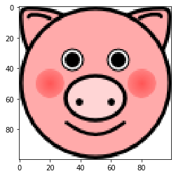

```python
import matplotlib.pyplot as plt
%matplotlib inline
plt.imshow(image)
```

Bezpiecznie jest dodawać timeout (limit wykonania) do każdego zapytania, ponieważ wtedy mamy pewność, że program skończy swoje wykonanie, niezależenie od połączenia z serwerem, który odpytujemy.

```python
def get_with_timeout(timeout):
    try:
        response = requests.get('https://httpbin.org/delay/1', timeout=timeout)
    except requests.exceptions.Timeout:
        print(f'Request took to long!')
    else:
        print(f'Status code: {response.status_code}, Took: {response.elapsed}')


get_with_timeout(2)
get_with_timeout(0.2)
```

```
Status code: 200, Took: 0:00:01.862213
Request took to long!
```

## Pobranie prawdziwych danych

Skorzystamy z danych udostępnianych przez [MetaWeather](https://www.metaweather.com/). Strona ta zawiera dane z różnych prognoz pogód, zarówno dalekosiężnych (tydzień w przód), jak i z tego samego dnia.

API posiada trzy *endpointy* (adresy które można odpytać):

- szukanie lokacji:
  - `/api/location/search/?query=(query)` - po zapytaniu `query`
  - `/api/location/search/?lattlong=(latt),(long)` - po koordynatach
- dane dla lokacji (krótki opis lokacji i dane z prognozą do kilku dni w przód):
  - `/api/location/(woeid)/` - `woeid` to id lokacji
- dane dla lokacji na konkretny dzień pogrupowane po dacie (malejąco):
  - `/api/location/(woeid)/(date)/` - `date` ma format `yyyy/mm/dd`

```python
from urllib.parse import urljoin
import requests

API_URL = 'https://www.metaweather.com/api/'

# Spróbujmy znaleźć warszawę
location_url = urljoin(API_URL, 'location/search')
response = requests.get(location_url, params=dict(query='Warszawa'))
print(response.url)
print(f'Status code: {response.status_code}, Took: {response.elapsed}')
print(response.json())
```

```
https://www.metaweather.com/api/location/search/?query=Warszawa
Status code: 200, Took: 0:00:00.094909
[]
```

```python
# Trzeba pamiętać, że nie wszystko będzie po polsku...
response = requests.get(location_url, params=dict(query='War'))
print(response.url)
print(f'Status code: {response.status_code}, Took: {response.elapsed}')
print(response.json())
```

```
https://www.metaweather.com/api/location/search/?query=War
Status code: 200, Took: 0:00:00.372899
[{'title': 'Warsaw', 'location_type': 'City', 'woeid': 523920, 'latt_long': '52.235352,21.009390'}, {'title': 'Newark', 'location_type': 'City', 'woeid': 2459269, 'latt_long': '40.731972,-74.174179'}]
```

```python
# Wyciągnijmy potrzebny id
woeid = response.json()[0]['woeid']
```

Zobaczmy jak wygląda odpowiedź z endpointu dla lokacji

```python
location_url = urljoin(API_URL, f'location/{woeid}')
response = requests.get(location_url)
print(response.url)
print(f'Status code: {response.status_code}, Took: {response.elapsed}')

# Dodanie ładnego wyglądu
import json

print(json.dumps(response.json(), indent=4))
```

```
https://www.metaweather.com/api/location/523920/
Status code: 200, Took: 0:00:00.706654
{
    "consolidated_weather": [
        {
            "id": 4992686736015360,
            "weather_state_name": "Light Cloud",
            "weather_state_abbr": "lc",
            "wind_direction_compass": "SSE",
            "created": "2019-12-19T22:22:01.929888Z",
            "applicable_date": "2019-12-20",
            "min_temp": 5.16,
            "max_temp": 11.085,
            "the_temp": 7.959999999999999,
            "wind_speed": 7.766542230130703,
            "wind_direction": 153.83270716458847,
            "air_pressure": 1009.0,
            "humidity": 81,
            "visibility": 10.910967450091466,
            "predictability": 70
        },
        {
            "id": 5764162116386816,
            "weather_state_name": "Light Rain",
            "weather_state_abbr": "lr",
            "wind_direction_compass": "S",
            "created": "2019-12-19T22:22:04.998053Z",
            "applicable_date": "2019-12-21",
            "min_temp": 6.609999999999999,
            "max_temp": 9.96,
            "the_temp": 8.72,
            "wind_speed": 5.712567294270792,
            "wind_direction": 190.65541999283846,
            "air_pressure": 995.0,
            "humidity": 83,
            "visibility": 9.125146643601369,
            "predictability": 75
        },
        {
            "id": 6300486158254080,
```

[output cut: 106 more lines]

```
            "crawl_rate": 360
        },
        {
            "title": "World Weather Online",
            "slug": "world-weather-online",
            "url": "http://www.worldweatheronline.com/",
            "crawl_rate": 360
        }
    ],
    "title": "Warsaw",
    "location_type": "City",
    "woeid": 523920,
    "latt_long": "52.235352,21.009390",
    "timezone": "Europe/Warsaw"
}
```

Pobierzmy dane dla obecnego miesiąca..

```python
import csv
import datetime
import pathlib

def get_data(woeid, year, month, day):
    location_url = urljoin(API_URL, f'location/{woeid}/{year}/{month}/{day}')

    data = None
    try:
        response = requests.get(location_url, timeout=5)
    except requests.exceptions.Timeout:
        print(f'Request for: {location_url} took to long!')
    else:
        print(f'Status code: {response.status_code}, Took: {response.elapsed}')
        print(response.url)
        data = response.json()
    finally:
        print('-' * 15)
        return data

# Tworzenie folderu do pobrania danych
path = pathlib.Path.cwd() / 'weather_data'
path.mkdir(parents=True, exist_ok=True)

now = datetime.datetime.now()
for day in range(1, now.day + 1):
    data = get_data(523920, now.year, now.month, day)

    if data:
        file_name = f'{now.year}-{now.month}-{day}.csv'
        with open(path / file_name, 'w') as _file:
            writer = csv.DictWriter(_file, delimiter=',', quotechar='"', fieldnames=data[0].keys())
            writer.writeheader()
            writer.writerows(data)
```

```
Status code: 200, Took: 0:00:00.447247
https://www.metaweather.com/api/location/523920/2019/12/1/
---------------
Status code: 200, Took: 0:00:00.507760
https://www.metaweather.com/api/location/523920/2019/12/2/
---------------
Status code: 200, Took: 0:00:00.744758
https://www.metaweather.com/api/location/523920/2019/12/3/
---------------
Status code: 200, Took: 0:00:00.488168
https://www.metaweather.com/api/location/523920/2019/12/4/
---------------
Status code: 200, Took: 0:00:01.010623
https://www.metaweather.com/api/location/523920/2019/12/5/
---------------
Status code: 200, Took: 0:00:00.551011
https://www.metaweather.com/api/location/523920/2019/12/6/
---------------
Status code: 200, Took: 0:00:00.399478
https://www.metaweather.com/api/location/523920/2019/12/7/
---------------
Status code: 200, Took: 0:00:00.428671
https://www.metaweather.com/api/location/523920/2019/12/8/
---------------
Status code: 200, Took: 0:00:01.206066
https://www.metaweather.com/api/location/523920/2019/12/9/
---------------
Status code: 200, Took: 0:00:00.509330
https://www.metaweather.com/api/location/523920/2019/12/10/
---------------
Status code: 200, Took: 0:00:00.647712
https://www.metaweather.com/api/location/523920/2019/12/11/
---------------
Status code: 200, Took: 0:00:00.746130
https://www.metaweather.com/api/location/523920/2019/12/12/
---------------
Status code: 200, Took: 0:00:00.673177
https://www.metaweather.com/api/location/523920/2019/12/13/
---------------
Status code: 200, Took: 0:00:00.634890
https://www.metaweather.com/api/location/523920/2019/12/14/
---------------
Status code: 200, Took: 0:00:00.710029
https://www.metaweather.com/api/location/523920/2019/12/15/
---------------
Status code: 200, Took: 0:00:00.431017
https://www.metaweather.com/api/location/523920/2019/12/16/
---------------
Status code: 200, Took: 0:00:00.525749
https://www.metaweather.com/api/location/523920/2019/12/17/
---------------
Status code: 200, Took: 0:00:01.455235
https://www.metaweather.com/api/location/523920/2019/12/18/
---------------
Status code: 200, Took: 0:00:01.619382
https://www.metaweather.com/api/location/523920/2019/12/19/
---------------
Status code: 200, Took: 0:00:00.426728
https://www.metaweather.com/api/location/523920/2019/12/20/
---------------
```

## `pandas`

`pandas` to biblioteka *open-source* Pythona pozwalająca na analizę danych o strukturze, zbliżonej do relacyjnej bazy danych ale nie tylko. Główną zaletą tej biblioteki są dwie struktury:

- `Series` - jednowymiarowa tablica zmiennych tego samego typu, w której elementy mogą być poetykietowane,
- `DataFrame` - dwuwymiarowa tablica zmiennych, w których kolumnę można interpretować jako oddzielne `Series` danych. Głównym ograniczeniem jest równa długość kolumn wewnątrz jednej ramki danych, ale biblioteka udostępnia wygodne narzędzia do wypełniania luk.

Instalacja: `pip install pandas`

### Tworzenie DataFrame

```python
import pandas as pd

# Dwuwymuarowa tablica jest interpretowana jako lista wierszy
data = [["a", 1], ["b", 2], ["c", 3]]
pd.DataFrame(data, columns = ["litera", "liczba"])
```

|  | litera | liczba |
| --- | --- | --- |
| 0 | a | 1 |
| 1 | b | 2 |
| 2 | c | 3 |

```python
# Słownik zawiera tablice reprezentujące kolumny
data = {
    "litera": ["a", "b", "c"],
    "cyfra": [1, 2, 3]
}
pd.DataFrame(data)
```

|  | litera | cyfra |
| --- | --- | --- |
| 0 | a | 1 |
| 1 | b | 2 |
| 2 | c | 3 |

```python
# Lista słowników
data = [
    {"litera": "a", "cyfra": 1},
    {"litera": "b", "cyfra": 2},
    {"litera": "c", "cyfra": 3},
]
pd.DataFrame(data)
```

|  | litera | cyfra |
| --- | --- | --- |
| 0 | a | 1 |
| 1 | b | 2 |
| 2 | c | 3 |

### Indeks i kolumna

Indeks to zbiór etykiet jednoznacznie identyfikujących wiersz w serii lub ramce danych. Można go interpretować jak klucz w słowniku, ale bardziej ustrukturyzowany.

```python
# Stwórzmy dwie ramki danych
df_1 = pd.DataFrame({"litera": ["a", "b", "c"], "cyfra": [1, 2, 3], "cyfra2": [10, 20, 30], "cyfra3": [100, 200, 300]})
df_1
```

|  | litera | cyfra | cyfra2 | cyfra3 |
| --- | --- | --- | --- | --- |
| 0 | a | 1 | 10 | 100 |
| 1 | b | 2 | 20 | 200 |
| 2 | c | 3 | 30 | 300 |

```python
df_2 = pd.DataFrame({"litera": ["d", "b", "c"], "cyfra": [1, 2, 3], "cyfra2": [10, 20, 30], "cyfra3": [100, 200, 300]})
df_2
```

|  | litera | cyfra | cyfra2 | cyfra3 |
| --- | --- | --- | --- | --- |
| 0 | d | 1 | 10 | 100 |
| 1 | b | 2 | 20 | 200 |
| 2 | c | 3 | 30 | 300 |

```python
# Każda z ramek danych zawiera zbiór indeksów i kolumn, przy czym indeksy na chwilę obecną są generyczne
df_1.index, df_1.columns
```

```
(RangeIndex(start=0, stop=3, step=1),
 Index(['litera', 'cyfra', 'cyfra2', 'cyfra3'], dtype='object'))
```

```python
# Ponieważ indeksy w obu ramkach danych są identyczne
# oraz zgadza się liczba kolumn możemy wykonywać operacje
# analogicznie jak na macierzach numpy
df_1 + df_2
```

|  | litera | cyfra | cyfra2 | cyfra3 |
| --- | --- | --- | --- | --- |
| 0 | ad | 2 | 20 | 200 |
| 1 | bb | 4 | 40 | 400 |
| 2 | cc | 6 | 60 | 600 |

```python
# Do ramki można dodać indeks wprost
df_3 = df_1.copy()
df_3.index = list('efg')
df_3
```

|  | litera | cyfra | cyfra2 | cyfra3 |
| --- | --- | --- | --- | --- |
| e | a | 1 | 10 | 100 |
| f | b | 2 | 20 | 200 |
| g | c | 3 | 30 | 300 |

```python
# Albo poprzez przekwalfikowanie kolumny
df_1.set_index("litera")
```

| litera | cyfra | cyfra2 | cyfra3 |
| --- | --- | --- | --- |
| a | 1 | 10 | 100 |
| b | 2 | 20 | 200 |
| c | 3 | 30 | 300 |

**UWAGA**: zmiany na ramce danych tworzą nową ramkę danych, dlatego jeżeli chcemy zapisać wynik operacji musimy przypisać je do zmiennej (do tej samej jeżeli chcemy zmutować ramkę danych). Niektóre metody posiadają jenak parametr `inplace`, który od razu mutuję zmienną.

```python
# Ramka nie uległa zmianie
df_1
```

|  | litera | cyfra | cyfra2 | cyfra3 |
| --- | --- | --- | --- | --- |
| 0 | a | 1 | 10 | 100 |
| 1 | b | 2 | 20 | 200 |
| 2 | c | 3 | 30 | 300 |

```python
# Tu już tak
df_1.set_index("litera", inplace=True)
df_1
```

| litera | cyfra | cyfra2 | cyfra3 |
| --- | --- | --- | --- |
| a | 1 | 10 | 100 |
| b | 2 | 20 | 200 |
| c | 3 | 30 | 300 |

```python
# Indeks definiuje "wiersz" w ramce danych,
# dlatego ramki ze zmienionym indeksem nie dodadzą się w ten sam sposób
df_2.set_index("litera", inplace=True)
df_1 + df_2
```

| litera | cyfra | cyfra2 | cyfra3 |
| --- | --- | --- | --- |
| a | NaN | NaN | NaN |
| b | 4.0 | 40.0 | 400.0 |
| c | 6.0 | 60.0 | 600.0 |
| d | NaN | NaN | NaN |

Wartości `NaN` pojawiły się, dlatego, że wiersz z jednej ramki został dodany do `None`, co nie mogło dać poprawnego wyniku. W celu określenia wartości domyślnych zamiast z operatorów trzeba korzystać z metod.

```python
df_res = df_1.add(df_2, fill_value=0)
df_res
```

| litera | cyfra | cyfra2 | cyfra3 |
| --- | --- | --- | --- |
| a | 1.0 | 10.0 | 100.0 |
| b | 4.0 | 40.0 | 400.0 |
| c | 6.0 | 60.0 | 600.0 |
| d | 1.0 | 10.0 | 100.0 |

### Adresowanie w ramce danych

W ramce danych nadrzędna jest kolumna, dopiero później pojedyncza wartość. Ramka pozwala na dostęp do kolumny przez atrybut i nawiasy kwadratowe. Atrybut działa jednak tylko dla pojedynczej kolumny, której nazwa może być interpretowana jako poprawna nazwa atrybutu. Dostęp przez nawiasy kwadratowe pozwala wybieranie podzbioru kolumn, jak i kolumn o nietypowych nazwach.

```python
print(type(df_res.cyfra))
df_res.cyfra
```

```
<class 'pandas.core.series.Series'>
```

```
litera
a    1.0
b    4.0
c    6.0
d    1.0
Name: cyfra, dtype: float64
```

```python
print(type(df_res['cyfra']))
df_res['cyfra']
```

```
<class 'pandas.core.series.Series'>
```

```
litera
a    1.0
b    4.0
c    6.0
d    1.0
Name: cyfra, dtype: float64
```

```python
print(type(df_res[['cyfra', 'cyfra2']]))
df_res[['cyfra', 'cyfra2']]
```

```
<class 'pandas.core.frame.DataFrame'>
```

| litera | cyfra | cyfra2 |
| --- | --- | --- |
| a | 1.0 | 10.0 |
| b | 4.0 | 40.0 |
| c | 6.0 | 60.0 |
| d | 1.0 | 10.0 |

W celu wyciągnięcia danych wierszowo służą atrybuty `loc` (dostęp po nazwie w indeksie) i `iloc` (dostęp po kolejności w indeksie). Atrybuty te pozwalają na slicing, indeksowanie przez iterablę wartości oraz zapytanie logiczne.

```python
df_res.loc['a']
```

```
cyfra       1.0
cyfra2     10.0
cyfra3    100.0
Name: a, dtype: float64
```

```python
df_res.iloc[1]
```

```
cyfra       4.0
cyfra2     40.0
cyfra3    400.0
Name: b, dtype: float64
```

```python
df_res.iloc[1:]
```

| litera | cyfra | cyfra2 | cyfra3 |
| --- | --- | --- | --- |
| b | 4.0 | 40.0 | 400.0 |
| c | 6.0 | 60.0 | 600.0 |
| d | 1.0 | 10.0 | 100.0 |

```python
df_res[df_res.cyfra < 2]
```

| litera | cyfra | cyfra2 | cyfra3 |
| --- | --- | --- | --- |
| a | 1.0 | 10.0 | 100.0 |
| d | 1.0 | 10.0 | 100.0 |

### Modyfikowanie ramki

```python
# Dodanie kolumny. UWAGA: Kolumnę powinno dodawać się przez nawiasy kwadratowe
df_res['cyfra4'] = [1000, 2000, 3000, 4000]
df_res
```

| litera | cyfra | cyfra2 | cyfra3 | cyfra4 |
| --- | --- | --- | --- | --- |
| a | 1.0 | 10.0 | 100.0 | 1000 |
| b | 4.0 | 40.0 | 400.0 | 2000 |
| c | 6.0 | 60.0 | 600.0 | 3000 |
| d | 1.0 | 10.0 | 100.0 | 4000 |

```python
# Dodanie wiersza polega na stworzeniu nowej ramki o tej samej strukturze i dodania jej do już istniejącej
new_df = pd.DataFrame(
    [['e', 5, 50, 500, 5000]],
    columns=['litera', 'cyfra', 'cyfra2', 'cyfra3', 'cyfra4']
)
new_df.set_index(['litera'], inplace=True)
new_df
```

| litera | cyfra | cyfra2 | cyfra3 | cyfra4 |
| --- | --- | --- | --- | --- |
| e | 5 | 50 | 500 | 5000 |

```python
df_res = pd.concat([df_res, new_df])
df_res
```

| litera | cyfra | cyfra2 | cyfra3 | cyfra4 |
| --- | --- | --- | --- | --- |
| a | 1.0 | 10.0 | 100.0 | 1000 |
| b | 4.0 | 40.0 | 400.0 | 2000 |
| c | 6.0 | 60.0 | 600.0 | 3000 |
| d | 1.0 | 10.0 | 100.0 | 4000 |
| e | 5.0 | 50.0 | 500.0 | 5000 |

### Podgląd ramki

```python
# Podgląd n-pierwszych wierszy, przydatne dla dużych ramek.
df_res.head(3)
```

| litera | cyfra | cyfra2 | cyfra3 | cyfra4 |
| --- | --- | --- | --- | --- |
| a | 1.0 | 10.0 | 100.0 | 1000 |
| b | 4.0 | 40.0 | 400.0 | 2000 |
| c | 6.0 | 60.0 | 600.0 | 3000 |

```python
# Statystyki ramki
df_res.describe()
```

|  | cyfra | cyfra2 | cyfra3 | cyfra4 |
| --- | --- | --- | --- | --- |
| count | 5.000000 | 5.000000 | 5.000000 | 5.00000 |
| mean | 3.400000 | 34.000000 | 340.000000 | 3000.00000 |
| std | 2.302173 | 23.021729 | 230.217289 | 1581.13883 |
| min | 1.000000 | 10.000000 | 100.000000 | 1000.00000 |
| 25% | 1.000000 | 10.000000 | 100.000000 | 2000.00000 |
| 50% | 4.000000 | 40.000000 | 400.000000 | 3000.00000 |
| 75% | 5.000000 | 50.000000 | 500.000000 | 4000.00000 |
| max | 6.000000 | 60.000000 | 600.000000 | 5000.00000 |

### Wczytywanie danych

```python
df_1 = pd.read_csv(path / '2019-12-1.csv')
```

```python
df_1.head()
```

|  | id | weather_state_name | weather_state_abbr | wind_direction_compass | created | applicable_date | min_temp | max_temp | the_temp | wind_speed | wind_direction | air_pressure | humidity | visibility | predictability |
| --- | --- | --- | --- | --- | --- | --- | --- | --- | --- | --- | --- | --- | --- | --- | --- |
| 0 | 5449283434184704 | Heavy Cloud | hc | WSW | 2019-12-01T22:21:59.022143Z | 2019-12-01 | -0.825 | 1.475 | 1.875 | 3.814174 | 238.491163 | 1022.5 | 86 | 10.699701 | 71 |
| 1 | 6158400721256448 | Heavy Cloud | hc | WSW | 2019-12-01T19:21:59.534368Z | 2019-12-01 | -1.870 | 1.425 | 1.825 | 4.278132 | 245.513466 | 1024.0 | 81 | 10.699701 | 71 |
| 2 | 5610028356599808 | Heavy Cloud | hc | WSW | 2019-12-01T16:21:58.444553Z | 2019-12-01 | -1.860 | 1.620 | 1.825 | 4.474798 | 249.497022 | 1024.0 | 79 | 11.401540 | 71 |
| 3 | 4603298088747008 | Heavy Cloud | hc | WSW | 2019-12-01T13:21:58.652308Z | 2019-12-01 | -1.550 | 1.725 | 1.540 | 4.649610 | 248.831990 | 1023.5 | 82 | 11.226935 | 71 |
| 4 | 6114266643955712 | Heavy Cloud | hc | WSW | 2019-12-01T10:21:58.618134Z | 2019-12-01 | -1.630 | 1.760 | 1.445 | 5.132328 | 249.165370 | 1024.0 | 82 | 9.685623 | 71 |

```python
# Edytowanie już wczytanych danych
from datetime import datetime

df_1.created = df_1.created.apply(lambda x: datetime.strptime(x, '%Y-%m-%dT%H:%M:%S.%fZ'))
```

```python
df_1.head()
```

|  | id | weather_state_name | weather_state_abbr | wind_direction_compass | created | applicable_date | min_temp | max_temp | the_temp | wind_speed | wind_direction | air_pressure | humidity | visibility | predictability |
| --- | --- | --- | --- | --- | --- | --- | --- | --- | --- | --- | --- | --- | --- | --- | --- |
| 0 | 5449283434184704 | Heavy Cloud | hc | WSW | 2019-12-01 22:21:59.022143 | 2019-12-01 | -0.825 | 1.475 | 1.875 | 3.814174 | 238.491163 | 1022.5 | 86 | 10.699701 | 71 |
| 1 | 6158400721256448 | Heavy Cloud | hc | WSW | 2019-12-01 19:21:59.534368 | 2019-12-01 | -1.870 | 1.425 | 1.825 | 4.278132 | 245.513466 | 1024.0 | 81 | 10.699701 | 71 |
| 2 | 5610028356599808 | Heavy Cloud | hc | WSW | 2019-12-01 16:21:58.444553 | 2019-12-01 | -1.860 | 1.620 | 1.825 | 4.474798 | 249.497022 | 1024.0 | 79 | 11.401540 | 71 |
| 3 | 4603298088747008 | Heavy Cloud | hc | WSW | 2019-12-01 13:21:58.652308 | 2019-12-01 | -1.550 | 1.725 | 1.540 | 4.649610 | 248.831990 | 1023.5 | 82 | 11.226935 | 71 |
| 4 | 6114266643955712 | Heavy Cloud | hc | WSW | 2019-12-01 10:21:58.618134 | 2019-12-01 | -1.630 | 1.760 | 1.445 | 5.132328 | 249.165370 | 1024.0 | 82 | 9.685623 | 71 |

## `.gitignore`

Nie wszystkie pliki powinny być przechowywane w repozytorium. Może to wynikać z kilku powodów:

- wrażliwe dane (repozytorium może być "zbyt" publiczne),
- pliki są za duże (rzędu giga/terabajtów),
- pliki nie nadają się do przechowywania w GITcie (ich zmiany są trudne do analizowania lub powodują zajmowanie za dużego obszaru pamięci),
- są plikami roboczymi wynikającymi z działania kodu i mogą się różnić między uruchomieniami,
- plik jest brudnopisem,
- ...

W związku z tymi warunkami w repozytorium nie powinno się przechowywać:

- plików zawierających dane dostępowe do usług (*credentials*),
- danych, których analizujemy, chyba że:
  - nie zawierają danych wrażliwych lub dane te są zanonimizowane i,
  - nie zajmują dużo pamięci (do kilku MB) i,
  - są danymi wolnozmieniającymi się,
- jupyterowych notebooków,
- plików/folderów nie zawierających kodu lub bezpośrednio wykorzystywanych w kodzie np. plików `*.pyc`, folderu z danymi IDE (`.idea` dla PyCharm) etc.

W celu wykluczenia plików/folderów ze śledzenia ich przez repozytorium tworzy sie plik `.gitignore`. Plik ten zawiera wzorce ścieżek, które powinny być wyłączone ze śledzenia przez repozytorium.

Jeżeli plik jest już śledzony przez repozytorium zasada opisana w `.gitignore` nie będzie go dotyczyć dopóki nie usuniemy go ze śledzenia komendą: `git rm --cached <ścieżka_do_pliku>`.

Wzorce ścieżek odnoszą się do folderu w którym znajduje się plik `.gitignore` i do wszystkich ścieżek "poniżej". Pliki takie mogą znajdować się na każdym poziomie struktury plików repozytorium.

Ogólnie w repozytorium powinno znajdować się jedno, wersjonowane `.gitignore` umieszcznoe w głównym folderze repozytorium, zawierające ogólnie wykluczne ścieżki.

Niektóre zasady do wzorców:

- Pusta linia nie jest interpretowana
- `/` oddziela foldery
- `*` oznacza dowolny znak
- `!` oznacza zanegowanie wzorca (czyli plik jest znowu śledzony, mimo że poprzedni wzorzec go wykluczał)
- `#` oznacza komentarz

```python
%%bash
# Fragment .gitignore z tego repozytorium
head -n 10 ../.gitignore
```

```
# Project specific
.idea/*
pw_pwzn_z*/
*.ipynb

repos/*
!repos/Repo_import.Rmd
!repos/_tools/*

results/*
```

## Źródła / przydatne linki

- [Dokumentacja modułu `urllib.parse`](https://docs.python.org/3.7/library/urllib.parse.html#module-urllib.parse)
- [Dokumentacja modułu `requests`](https://requests.readthedocs.io/en/master/)
- [Stronka do testowania zapytań](https://httpbin.org/#/)
- [Lista publicznych API](https://github.com/public-apis/public-apis)
- [Dokumentacja modułu `pandas`](https://pandas.pydata.org/pandas-docs/stable/getting_started/overview.html)
- [Dokumentacja GITa do `.gitignore`](https://git-scm.com/docs/gitignore)
- [Lista przykładowych plików `.gitignore` dla różnych projektów](https://github.com/github/gitignore)